# LSTM_using_NP_array

Unleashing Creativity with Character-Level LSTM Text Generation

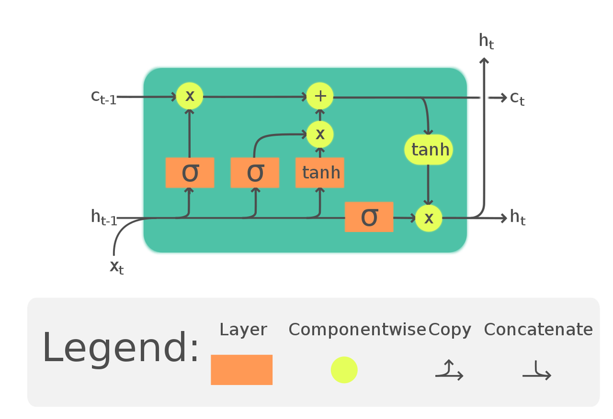

```python
from keras.models import Sequential
from keras.layers import Dense, Dropout, Embedding, Flatten, LSTM
import numpy as np
from keras.models import model_from_json
```

In this blog post, we delve into the intriguing world of character-level LSTM text generation using Keras, a popular deep learning library in Python.

**Model Architecture**: The model is built using the Sequential API of Keras. It consists of an LSTM layer followed by a dropout layer for regularization and a dense layer with a sigmoid activation function for binary classification.

```python
char_indices={'x': 0, 'i': 1, 'r': 2, '8': 3, 'c': 4, ',': 5, 'y': 6, '?': 7, 'h': 8, 'm': 9, 'z': 10, 'k': 11, '5': 12, 'a': 13, '0': 14, 'g': 15, ';': 16, ' ': 17, 'f': 18, 'u': 19, 'w': 20, 'n': 21, '4': 22, '!': 23, '2': 24, 'p': 25, 'd': 26, '"': 27, 'l': 28, '3': 29, '.': 30, 'UNK': 31, '6': 32, 'PAD': 33, 'o': 34, '7': 35, '1': 36, 'e': 37, ':': 38, 'q': 39, 'b': 40, 'j': 41, 't': 42, 's': 43, '9': 44, 'v': 45, "'": 46}
```

```python
maxlen = 1000
num_neurons = 40
model = Sequential()
model.add(LSTM(num_neurons,
return_sequences=True,
input_shape=(maxlen, len(char_indices.keys()))))
```

```python
model.add(Dropout(.2))
model.add(Flatten())
model.add(Dense(1, activation='sigmoid'))
model.compile('rmsprop', 'binary_crossentropy', metrics=['accuracy'])
model.summary()
```

```
Model: "sequential"
_________________________________________________________________
 Layer (type)                Output Shape              Param #
=================================================================
 lstm (LSTM)                 (None, 1000, 40)          14080

 dropout (Dropout)           (None, 1000, 40)          0

 flatten (Flatten)           (None, 40000)             0

 dense (Dense)               (None, 1)                 40001

=================================================================
Total params: 54,081
Trainable params: 54,081
Non-trainable params: 0
_________________________________________________________________
```

**Data Preparation**: The model is trained on input data (x_train) and target labels (y_train) loaded from numpy files. Similarly, test data (x_test) and labels (y_test) are loaded for evaluation.

```python
x_test= np.load('x_test.npy')
x_train= np.load('x_train.npy')
y_test= np.load('y_test.npy')
y_train= np.load('y_train.npy')
```

**Training**: The model is trained using the fit function, specifying batch size and number of epochs. Training data and validation data are provided for monitoring the model's performance.

```python
print(x_test.shape)
```

```
(29, 1000, 47)
```

**Model Saving**: After training, the model structure is serialized to a JSON file (char_lstm_model3.json), and the weights are saved to an HDF5 file (char_lstm_weights3.h5).

```python
batch_size = 10
epochs = 10
model.fit(x_train, y_train,
batch_size=batch_size,
epochs=epochs,
validation_data=(x_test, y_test))
```

```
<keras.callbacks.History at 0x7b097cd5fc10>
```

```python
model_structure = model.to_json()
with open("char_lstm_model3.json", "w") as json_file:
  json_file.write(model_structure)
model.save_weights("char_lstm_weights3.h5")
```

```python
# Function to generate text using the trained model

with open("char_lstm_model3.json", "r") as json_file:
    loaded_model_json = json_file.read()

model = model_from_json(loaded_model_json)
model.load_weights("char_lstm_weights3.h5")
model.compile('rmsprop', 'binary_crossentropy', metrics=['accuracy'])

def generate_text(model, input_text, max_length=10):
    generated_text = input_text[-maxlen:]  # Initialize the generated text with the last 'maxlen' characters of the input
    for _ in range(max_length - len(input_text)):
        encoded_input = np.zeros((1, maxlen, len(char_indices.keys())))
        for t, char in enumerate(generated_text[-maxlen:]):
            encoded_input[0, t, char_indices[char]] = 1.0

        predicted_char_prob = model.predict(encoded_input)[0][0]
        predicted_char = next((char for char, index in char_indices.items() if index == round(predicted_char_prob)), "UNK")
        generated_text += predicted_char

    return generated_text

# User input
user_input = input("Enter a seed text: ")

# Generate text and display it
generated_text = generate_text(model, user_input)
print("Generated text:")
print(generated_text)
```

[output not shown]